# Forecasting UK Natural Gas Consumption

Ayomide Olajide, Student Number 221112858

2025-03-08

## Overview

Energy Consumption is a critical indicator of a nation’s economic activity and industrial growth. The Uk natural gas consumption figures provide an insight into how energy demand has evolved over time and what we might expect in the future.

In this analysis, we will explore the UKgas dataset, which records Uk natural gas consumption every quarter from **1960** to **1986**. The objective is to discover trends, seasonality differences, and to build an accurate forecasting model. Rising energy costs are a topic in today’s news and understand the underlying trends can help business plan and prepare for future needs.

## Project Objectives

1. Understand long term trends and fluctuations of energy consumptions.
2. Examining seasonality to discover if there are consistent changes in gas usage across the year?
3. Building a forecasting model using Prophet to predict future gas consumption and examine the results.

## 1. Installing Packages

To start, we must install Prophet, which is a forecasting tool developed by Meta. We use ‘remotes’ to install it from Github to ensure we have the latest version. After this is done, we are ready to start the analysis.

## 2. Visualizing the data

We can first start by visualizing the dataset. The code below plots the time series, with time on the x axis and gas consumption on the y axis.

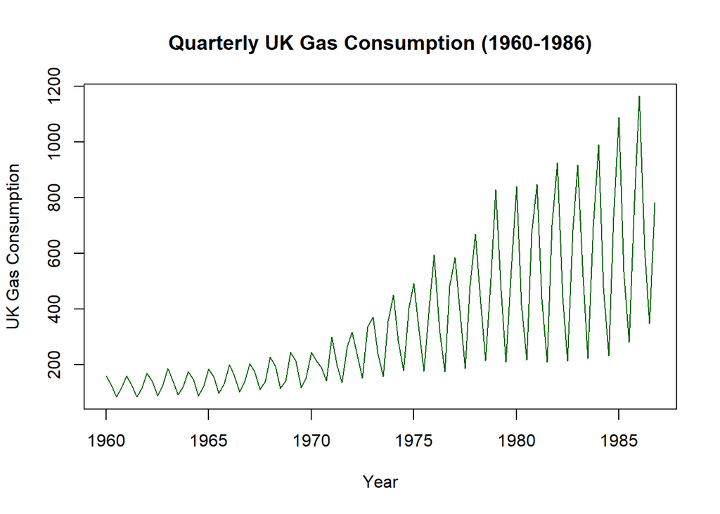

```r
plot(UKgas, main="Quarterly UK Gas Consumption (1960-1986)",
     ylab="UK Gas Consumption", xlab="Year",
     col="darkgreen", type="l")
```

## 3. Further Visualization

### Decomposition

Further analysis can be done by using the `decompose` function. This function breaks up the time series into trend, seasonality, and residuals to give us a clearer picture.

```r
decomposed = decompose(UKgas, type="multiplicative")
```

Let us plot the results:

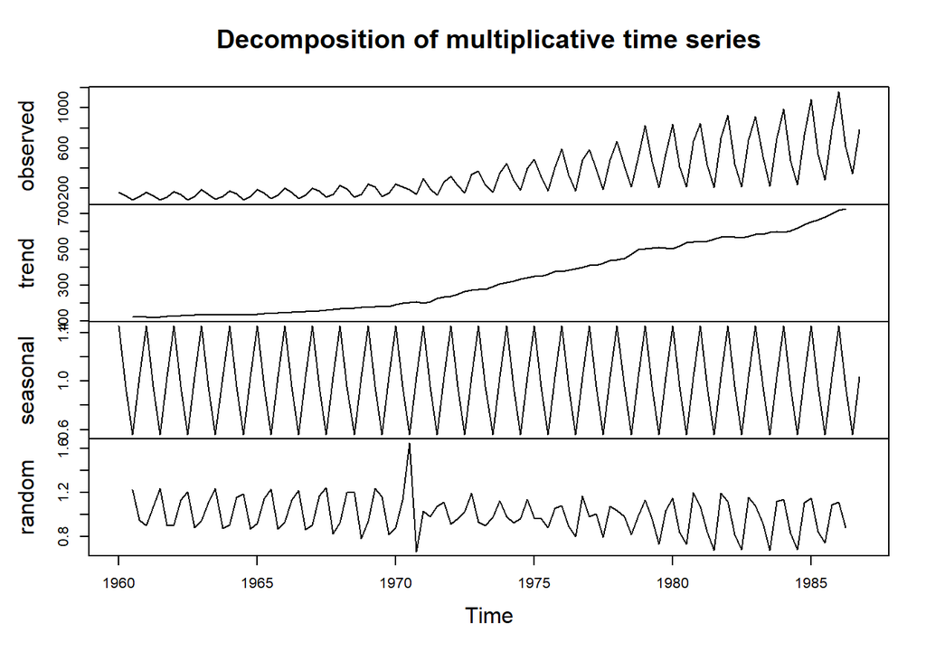

```r
plot(decomposed)
```

### Key Observations

- The ‘trend’ graph shows UK gas consumption has been steadily rising from **1960** to **1985**, as expected.
- The ‘seasonal’ graph reveals the seasonal fluctuations of Uk gas consumption. In the winter, as temperatures drop, energy consumption rises as people need to heat their homes. When temperatures rise again in the summer, energy consumption decreases.
- As for the residuals, we can see that there are some small random variations, such as the spike in 1970, however these are not large enough to significantly impact the overall results.

### Specific Timeframe

We can also visualize the data for a shorter timeframe using the `window` function. The following plot inspects the period from **1972** to **1982**

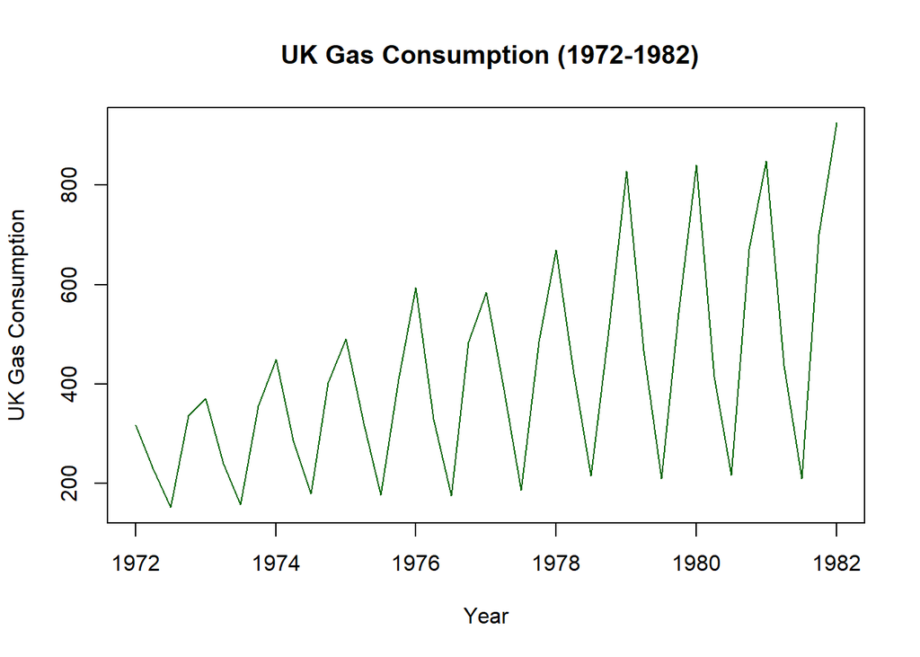

```r
windowed_gas = window(UKgas, start=1972, end=1982)
plot(windowed_gas, main=" UK Gas Consumption (1972-1982)", col="darkgreen",
     ylab="UK Gas Consumption", xlab="Year", type="l")
```

### Benefits of varying timeframes

- Being able to zoom in on specific periods can allow us to gain a deeper understanding of short term trends, and assess if there are other potential factors that influence gas consumption, such as changes in economic policy.

## 4. Linear Regression Model

A linear regression model gives a basic view of UK gas consumption trends. It helps us see if usage is going up or down over time and at what pace by fitting a simple trend line.

To build this model, we first convert time into a numeric variable, and then convert data into a numeric vector.

```r
time_values = as.numeric(time(UKgas))
gas_values = as.numeric(UKgas)
```

We then use the `lm()` function to fit the model and generate the summary statistics.

```r
lm_model = lm(gas_values ~ time_values)

summary(lm_model)
```

```
##
## Call:
## lm(formula = gas_values ~ time_values)
##
## Residuals:
##     Min      1Q  Median      3Q     Max
## -368.57  -85.50    1.20   69.86  525.95
##
## Coefficients:
##               Estimate Std. Error t value Pr(>|t|)
## (Intercept) -46604.608   4130.636  -11.28   <2e-16 ***
## time_values     23.788      2.093   11.36   <2e-16 ***
## ---
## Signif. codes:  0 '***' 0.001 '**' 0.01 '*' 0.05 '.' 0.1 ' ' 1
##
## Residual standard error: 169.5 on 106 degrees of freedom
## Multiple R-squared:  0.5492, Adjusted R-squared:  0.545
## F-statistic: 129.2 on 1 and 106 DF,  p-value: < 2.2e-16
```

Let us plot the results

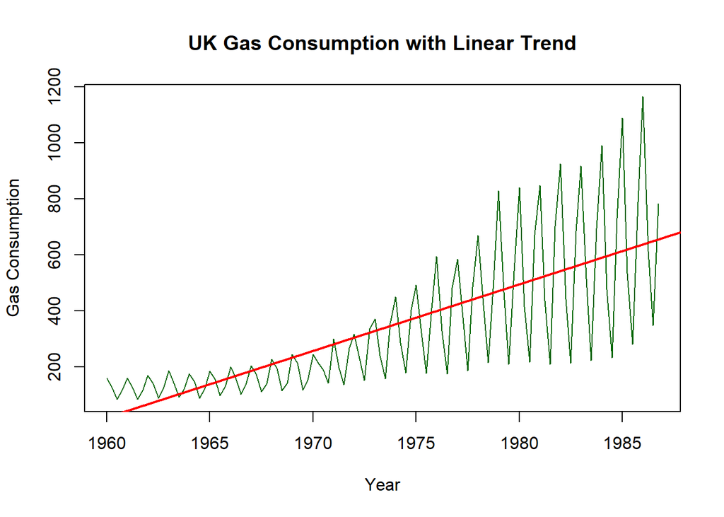

```r
plot(UKgas, main="UK Gas Consumption with Linear Trend", col="darkgreen",
     ylab="Gas Consumption", xlab="Year", type="l")
abline(lm_model, col="red", lwd=2)
```

### Regression Analysis

#### Trendline

- The red line shows the general trend, which shows steady growth over time, reflecting higher energy use from 1960 to 1985.
- The key takeaway is a positive trend with a coefficient of **23.788**, reinforcing the idea of rising consumption.

#### Statistical Significance

- The model has a p-value of **<2e-16**, suggesting that there is strong evidence time influences gas consumption.

#### Fit

- The R squared value of **0.5492** suggests that about **55%** of the variation in gas consumption can be explained only by time, however the Residual standard error of **169.5** shows that not all the variation is captured by time.
- Overall the model is a solid fit, however there is evidence to suggest that additional factors may influence gas consumption beyond just time.

## 5. Creating a forecast using Prophet

Next, we are going to use Prophet to create a forecast to predict the UK gas consumption for the next **20** quarters, based on the current data available to us.

```r
UKgas.df = data.frame(
    ds=zoo::as.yearmon(time(UKgas)),
    y=UKgas)
```

We then make a future data frame for 20 periods (5 years) and use this to create a predicted data frame using the `predict` function. We set out frequency to `quarter`to ensure the predictions follow the nature of the dataset. Our predicted model plot is as follows:

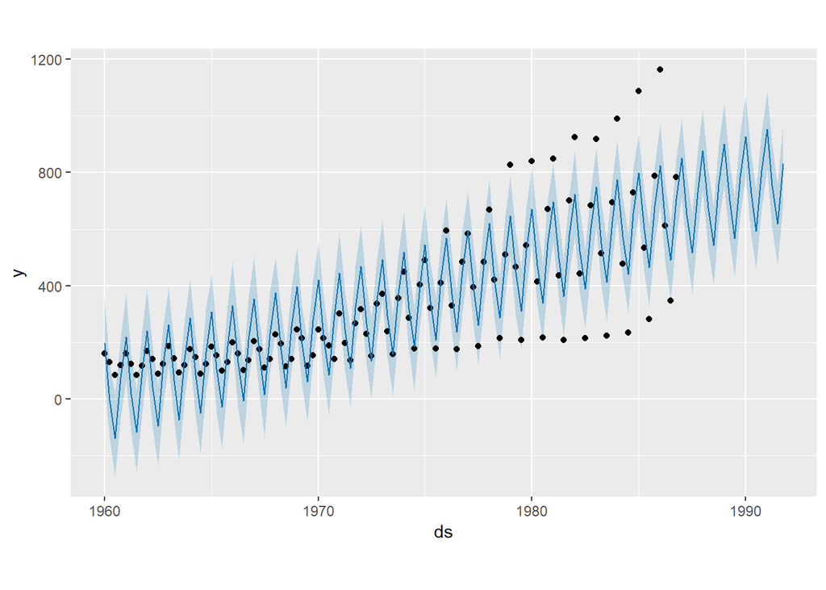

```r
model_gas = prophet::prophet(UKgas.df)


future_dataframe = prophet::make_future_dataframe(model_gas, periods=20, freq="quarter")


predicted_dataframe = predict(model_gas, future_dataframe)
plot(model_gas, predicted_dataframe)
```

### Observations

- The forecast suggests UK gas consumption will continue increasing.
- Seasonal effects remain consistent, meaning gas demand fluctuates predictably.

## 6. Examining forecast results

Now that we have run our predicted model, we can do some analysis.

### Checking the confidence intervals

The confidence intervals help us to understand how much certainty the model has in its predictions. We can use the `yhat` function in Prophet that represents the predicted values, and assess the upper and lower bounds ( `yhat_lower` and `yhat_upper`) of the confidence interval.

```r
head(predicted_dataframe[, c('ds', 'yhat', 'yhat_lower', 'yhat_upper')],12)
```

```
##            ds        yhat yhat_lower yhat_upper
## 1  1960-01-01  197.081175   62.02408  349.04275
## 2  1960-04-01   -4.817374 -138.68993  126.08996
## 3  1960-07-01 -138.025678 -272.74238   15.95720
## 4  1960-10-01   77.187060  -66.86029  215.09989
## 5  1961-01-01  219.609022   64.92578  370.17326
## 6  1961-04-01   18.177628 -114.12127  157.78001
## 7  1961-07-01 -116.360874 -254.98336   29.97010
## 8  1961-10-01   98.235017  -48.30507  242.16733
## 9  1962-01-01  241.795329  100.11328  388.57840
## 10 1962-04-01   41.260923  -98.70691  186.05202
## 11 1962-07-01  -94.520998 -236.89712   46.16436
## 12 1962-10-01  119.326470  -27.27376  251.39407
```

### Observations

#### Interval Size

The confidence intervals are consistently fairly wide, representing some uncertainty in periods.

#### Negative Lower Bounds

- Some predictions cross zero (April 1960, July 1960, July 1961, July 1962). The lower bounds of these periods are negative, which shows a possibility of negative values at this point.
- This indicates a strong seasonal aspect to the forecast, where gas consumption dips in certain quarters.

## 7. Forecasting to the Modern Day (2025)

Our previous model predicted 5 years into the future, but what happens if we predict 39 years into the future, i.e to the present day. By slightly altering our code above, we can use Prophet to forecast Gas consumption to the modern day, and compare it to real statistics.

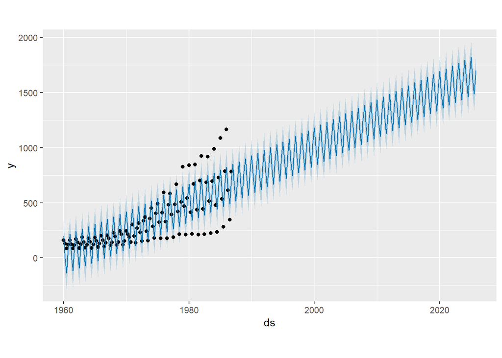

## 8. Conclusion

This analysis provides a fascinating insight into the evolving landscape of UK natural gas consumption. By examining historical trends and forecasting future demand, we’ve uncovered patterns shaped by both predictable seasonal fluctuations and unpredictable events like the 1979 energy crisis.